# Banking Marketing: Exploratory Data Analysis

- Show All Code
- Hide All Code
- View Source

ST 558 Project 2

Author

Stanley Xiao

## Introduction

This report explores the Bank Marketing dataset which contains information about customers contacted during a direct marketing campaign conducted by a Portuguese banking institution. The primary objective is to investigate how customer characteristics and campaign interactions relate to whether a customer subscribes to a term deposit.

The response variable, `y`, records whether a customer subscribed to a term deposit.

The dataset was obtained from [Kaggle: Banking Dataset (Marketing Targets)](https://www.kaggle.com/datasets/prakharrathi25/banking-dataset-marketing-targets), which is based on the [UCI Bank Marketing dataset](https://archive.ics.uci.edu/dataset/222/bank+marketing)

## Data Preparation

The original dataset was obtained from Kaggle and consisted of two files, ‘train.csv’ and ‘test.csv’. The datasets were combined, duplicate observations were removed, and categorical variables were converted to factors. The cleaned dataset was then saved as `bank_clean.csv` for use in both the Shiny application and this exploratory analysis.

### Original Data Cleaning Process

The following code documents the initial data preparation procedure. It is not executed during rendering because the cleaned dataset has already been created.

```r
library(tidyverse)

# Read both datasets
train <- read_delim("Dataset/train.csv", delim = ";")
test <- read_delim("Dataset/test.csv", delim = ";")

# Combine train and test datasets and remove duplicate rows
bank_data <- bind_rows(train, test)
bank_data <- distinct(bank_data)

# Check for remaining duplicates
sum(duplicated(bank_data))

# Clean & format
bank_data <- bank_data |>
  mutate(across(where(is.character), as.factor))

# Save combined clean data for the Shiny app
write_csv(bank_data, "Dataset/bank_clean.csv")
```

### Loading the Cleaned Dataset

The resulting dataset contains 45211 observations and 17 variables.

## Dataset Overview

### Dataset Dimensions

```r
# Report the number of observations and variables
data.frame(
  Observations = nrow(bank_data),
  Variables = ncol(bank_data)
) |>
  kable(
    caption = "Dataset Dimensions"
  )
```

Dataset Dimensions

| Observations | Variables |
| --- | --- |
| 45211 | 17 |

### Variable Types

```r
# Summarize the type of each variable
data.frame(
  Variable = names(bank_data),
  Data_Type = sapply(bank_data, function(x) class(x)[1])
) |>
  kable(
    caption = "Variables and Data Types"
  )
```

Variables and Data Types

|  | Variable | Data_Type |
| --- | --- | --- |
| age | age | integer |
| job | job | factor |
| marital | marital | factor |
| education | education | factor |
| default | default | factor |
| balance | balance | integer |
| housing | housing | factor |
| loan | loan | factor |
| contact | contact | factor |
| day | day | integer |
| month | month | factor |
| duration | duration | integer |
| campaign | campaign | integer |
| pdays | pdays | integer |
| previous | previous | integer |
| poutcome | poutcome | factor |
| y | y | factor |

### Missing Values

```r
# Count missing values for each variable
missing_table <- data.frame(
  Variable = names(bank_data),
  Missing_Values = sapply(bank_data, function(x) sum(is.na(x)))
)

missing_table |>
  kable(
    caption = "Missing Values by Variable"
  )
```

Missing Values by Variable

|  | Variable | Missing_Values |
| --- | --- | --- |
| age | age | 0 |
| job | job | 0 |
| marital | marital | 0 |
| education | education | 0 |
| default | default | 0 |
| balance | balance | 0 |
| housing | housing | 0 |
| loan | loan | 0 |
| contact | contact | 0 |
| day | day | 0 |
| month | month | 0 |
| duration | duration | 0 |
| campaign | campaign | 0 |
| pdays | pdays | 0 |
| previous | previous | 0 |
| poutcome | poutcome | 0 |
| y | y | 0 |

Note that values such as “unknown” are recorded categories in this dataset and are not automatically treated as missing values.

## Categorical Variable Summaries

### Term Deposit Subscription

```r
# Calculate subscription frequencies and percentages
subscription_table <- bank_data |>
  count(y, name = "Frequency") |>
  mutate(
    Percentage = round(
      100 * Frequency / sum(Frequency),
      2
    )
  )

subscription_table |>
  kable(caption = "Term Deposit Subscription Frequencies")
```

Term Deposit Subscription Frequencies

| y | Frequency | Percentage |
| --- | --- | --- |
| no | 39922 | 88.3 |
| yes | 5289 | 11.7 |

This table shows the distribution of the response variable. The percentages help assess whether term deposit subscriptions are balanced between customers who subscribed and those who did not.

### Customer Job Categories

```r
# Calculate frequencies for customer occupations
job_table <- bank_data |>
  count(job, name = "Frequency") |>
  mutate(
    Percentage = round(
      100 * Frequency / sum(Frequency),
      2
    )
  ) |>
  arrange(desc(Frequency))

job_table |>
  kable(
    caption = "Customer Job Frequencies"
  )
```

Customer Job Frequencies

| job | Frequency | Percentage |
| --- | --- | --- |
| blue-collar | 9732 | 21.53 |
| management | 9458 | 20.92 |
| technician | 7597 | 16.80 |
| admin. | 5171 | 11.44 |
| services | 4154 | 9.19 |
| retired | 2264 | 5.01 |
| self-employed | 1579 | 3.49 |
| entrepreneur | 1487 | 3.29 |
| unemployed | 1303 | 2.88 |
| housemaid | 1240 | 2.74 |
| student | 938 | 2.07 |
| unknown | 288 | 0.64 |

This table identifies the most common occupational categories among customers in the dataset.

### Subscription Outcome by Education

```r
# Calculate frequencies for education and subscription
education_subscription <- bank_data |>
  count(education, y, name = "Frequency") |>
  group_by(education) |>
  mutate(
    Percentage_Within_Education = round(
      100 * Frequency / sum(Frequency),
      2
    )
  ) |>
  ungroup()

education_subscription |>
  kable(
    caption = "Subscription Outcomes by Education Level"
  )
```

Subscription Outcomes by Education Level

| education | y | Frequency | Percentage_Within_Education |
| --- | --- | --- | --- |
| primary | no | 6260 | 91.37 |
| primary | yes | 591 | 8.63 |
| secondary | no | 20752 | 89.44 |
| secondary | yes | 2450 | 10.56 |
| tertiary | no | 11305 | 84.99 |
| tertiary | yes | 1996 | 15.01 |
| unknown | no | 1605 | 86.43 |
| unknown | yes | 252 | 13.57 |

This two-way summary compares subscription outcomes across education categories. Percentages are calculated within each education group, allowing comparisons between groups at different sizes.

## Numerical Variable Summaries

### Overall Descriptive Statistics

```r
# Select numerical variables
numeric_vars <- c(
  "age", "balance", "duration", "campaign", "pdays", "previous"
)

# Calculate descriptive statistics for each variable
numeric_summary <- bind_rows(lapply(numeric_vars, function(variable) {

  x <- bank_data[[variable]]
  x <- x[!is.na(x)]

  data.frame(
    Variable = variable,
    Count = length(x),
    Mean = mean(x),
    Median = median(x),
    SD = sd(x),
    Min = min(x),
    Max = max(x)
  )
}))

# Round numerical results
numeric_summary <- numeric_summary |>
  mutate(
    across(
      c(Mean, Median, SD, Min, Max),
      ~ round(.x, 2)
    )
  )

numeric_summary |>
  kable(
    caption = "Overall Numerical Descriptive Statistics"
  )
```

Overall Numerical Descriptive Statistics

| Variable | Count | Mean | Median | SD | Min | Max |
| --- | --- | --- | --- | --- | --- | --- |
| age | 45211 | 40.94 | 39 | 10.62 | 18 | 95 |
| balance | 45211 | 1362.27 | 448 | 3044.77 | -8019 | 102127 |
| duration | 45211 | 258.16 | 180 | 257.53 | 0 | 4918 |
| campaign | 45211 | 2.76 | 2 | 3.10 | 1 | 63 |
| pdays | 45211 | 40.20 | -1 | 100.13 | -1 | 871 |
| previous | 45211 | 0.58 | 0 | 2.30 | 0 | 275 |

The numerical summary describes the center, spread, and range of the selected quantitative variables. Differences between means and medians may suggest skewed distributions or extreme observations.

For the variable `pdays`, special values like ‘-1’ may indicate that a customer was not previously contacted. These values should be interpreted according to the dataset documentation rather than treated as ordinary elapsed days.

### Numerical Summaries by Subscription Outcome

```r
# Compare age, balance, and call duration by outcome
grouped_summary <- bank_data |>
  group_by(y) |>
  summarise(
    Count = n(),
    Mean_Age = mean(age, na.rm = TRUE),
    Median_Age = median(age, na.rm = TRUE),
    Mean_Balance = mean(balance, na.rm = TRUE),
    Median_Balance = median(balance, na.rm = TRUE),
    Mean_Duration = mean(duration, na.rm = TRUE),
    Median_Duration = median(duration, na.rm = TRUE),
    .groups = "drop"
  ) |>
  mutate(
    across(
      where(is.numeric),
      ~ round(.x, 2)
    )
  )

grouped_summary |>
  kable(
    caption = "Numerical Characteristics by Subscription Outcome"
  )
```

Numerical Characteristics by Subscription Outcome

| y | Count | Mean_Age | Median_Age | Mean_Balance | Median_Balance | Mean_Duration | Median_Duration |
| --- | --- | --- | --- | --- | --- | --- | --- |
| no | 39922 | 40.84 | 39 | 1303.71 | 417 | 221.18 | 164 |
| yes | 5289 | 41.67 | 38 | 1804.27 | 733 | 537.29 | 426 |

This grouped summary compares customers who subscribed to a term deposit with those who did not. It provides an initial assessment of differences in age, account balance, and call duration between the two groups.

Because this is an observational dataset, any differences should be interpreted as associations rather than evidence of causation.

## Exploratory Data Visualizations

The following visualizations explore customer demographics, account balances, marketing campaign characteristics, and term deposit subscription outcomes. Both univariate and multivariate plots are included to identify patterns and differences across customer groups.

### Plot 1: Distribution of Customer Age

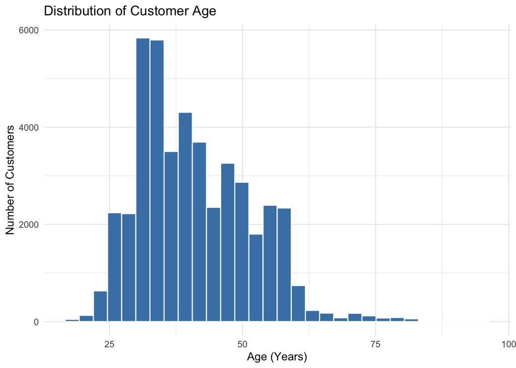

```r
# Univariate histogram of customer age
ggplot(bank_data, aes(x = age)) +
  geom_histogram(
    bins = 30,
    fill = "steelblue",
    color = "white"
  ) +
  labs(
    title = "Distribution of Customer Age",
    x = "Age (Years)",
    y = "Number of Customers"
  ) +
  theme_minimal()
```

The distribution of customer age is moderately right-skewed, with most customers concentrated between 25 and 60 years old. The highest frequencies occur among customers in their early to mid-30s, while the number of customers generally decreases at older ages. Relatively few customers are younger than 25 or older than 65. These findings suggest that the bank’s marketing campaign primarily reached working-age adults.

### Plot 2: Distribution of Account Balances

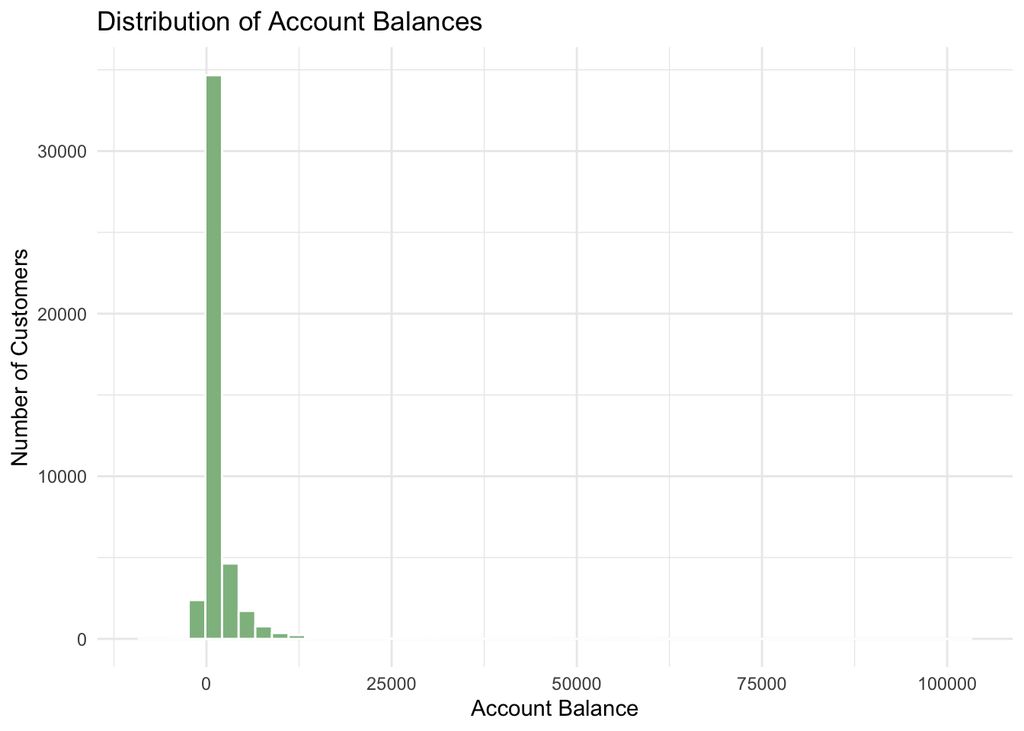

```r
# Univariate histogram of customer account balances
ggplot(bank_data, aes(x = balance)) +
  geom_histogram(
    bins = 50,
    fill = "darkseagreen",
    color = "white"
  ) +
  labs(
    title = "Distribution of Account Balances",
    x = "Account Balance",
    y = "Number of Customers"
  ) +
  theme_minimal()
```

The distribution of account balances is strongly right-skewed. Most customers have relatively low account balances, while a small number have exceptionally high balances, exceeding 100,000 in some cases. The presence of extreme values suggests that the median may provide a more representative measure of a typical customer’s account balance than the mean.

### Plot 3: Subscription Outcome by Education Level

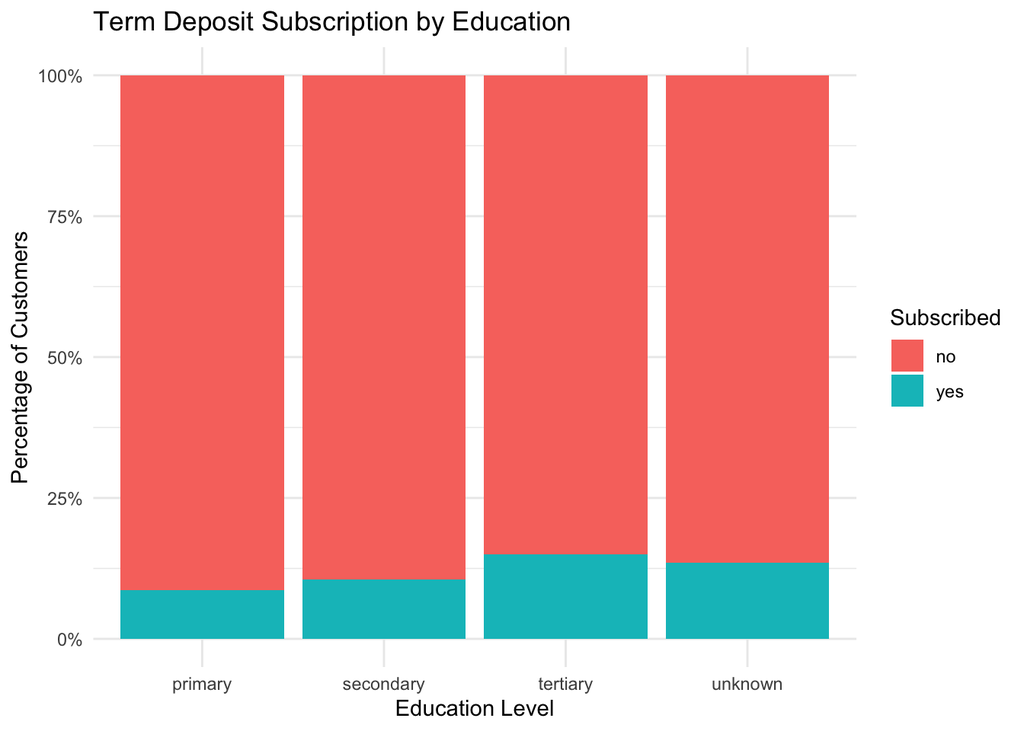

```r
# Multivariate plot: education and subscription outcome
ggplot(
  bank_data,
  aes(x = education, fill = y)
) +
  geom_bar(position = "fill") +
  scale_y_continuous(
    labels = scales::percent
  ) +
  labs(
    title = "Term Deposit Subscription by Education",
    x = "Education Level",
    y = "Percentage of Customers",
    fill = "Subscribed"
  ) +
  theme_minimal()
```

Term deposit subscription rates vary across education levels. Customers with tertiary education have the highest observed subscription proportion, while those with primary education have the lowest. This suggests an association between education level and subscription outcome, although the analysis does not establish a causal relationship.

### Plot 4: Account Balance by Subscription Outcome

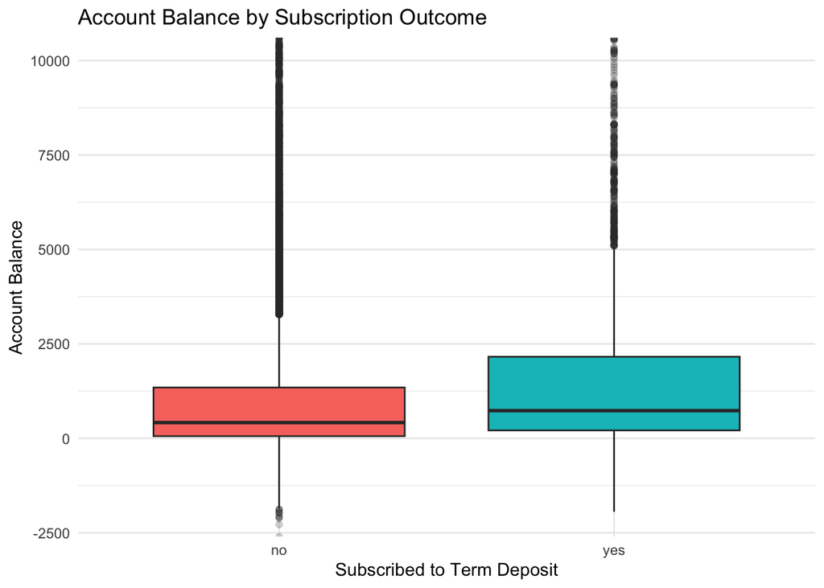

```r
# Multivariate boxplot: balance and subscription outcome
ggplot(
  bank_data,
  aes(x = y, y = balance, fill = y)
) +
  geom_boxplot(
    outlier.alpha = 0.2
  ) +
  labs(
    title = "Account Balance by Subscription Outcome",
    x = "Subscribed to Term Deposit",
    y = "Account Balance",
    fill = "Subscribed"
  ) +
  coord_cartesian(ylim = c(-2000, 10000)) +
  theme_minimal() +
  theme(
    legend.position = "none"
  )
```

Customers who subscribed to a term deposit appear to have a higher median account balance than customers who did not subscribe. However, the distributions overlap substantially, and both groups contain numerous high-balance outliers. Therefore, account balance alone may not clearly distinguish between subscription outcomes.

The vertical axis of the boxplots is restricted to improve visibility of the central distributions; observations outside the displayed range remain included in the boxplot calculations.

### Plot 5: Age and Account Balance by Subscription Outcome

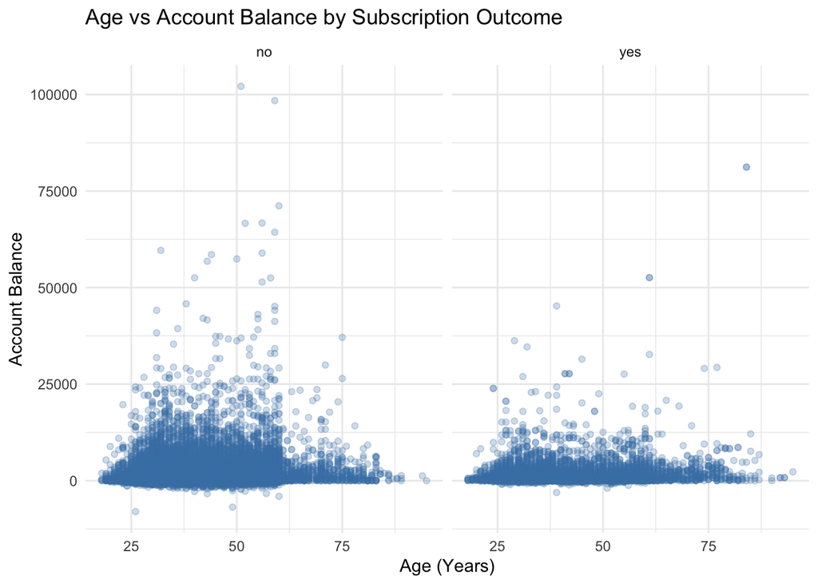

```r
# Multivariate scatterplot with faceting
ggplot(
  bank_data,
  aes(x = age, y = balance)
) +
  geom_point(
    alpha = 0.25,
    color = "steelblue"
  ) +
  facet_wrap(~ y) +
  labs(
    title = "Age vs Account Balance by Subscription Outcome",
    x = "Age (Years)",
    y = "Account Balance"
  ) +
  theme_minimal()
```

The faceted scatterplot does not reveal a strong linear relationship between customer age and account balance in either subscription group. Most customers have relatively low account balances across a wide range of ages, while a small number have unusually high balances. The two subscription groups show broadly similar patterns, suggesting that age and account balance alone may not provide a clear separation between subscription outcomes.

### Plot 6: Subscription Rates by Job and Education

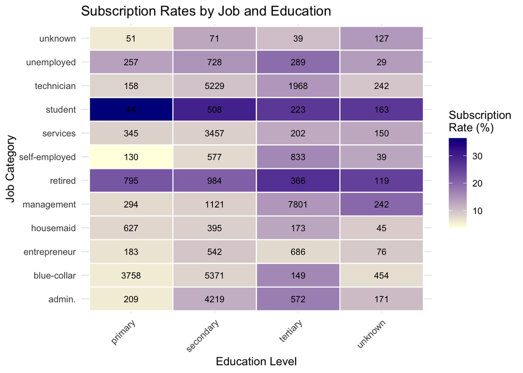

```r
# Calculate subscription percentages for each job and education group
heatmap_data <- bank_data |>
  group_by(job, education) |>
  summarise(
    Subscription_Rate = mean(y == "yes", na.rm = TRUE) * 100,
    Customer_Count = n(),
    .groups = "drop"
  )

# Multivariate heatmap of subscription rates
ggplot(
  heatmap_data,
  aes(
    x = education,
    y = job,
    fill = Subscription_Rate
  )
) +
  geom_tile(
    color = "white",
    linewidth = 0.5
  ) +
  geom_text(
    aes(label = Customer_Count),
    size = 3,
    color = "black"
  ) +
  scale_fill_gradient(
    low = "lightyellow",
    high = "darkblue"
  ) +
  labs(
    title = "Subscription Rates by Job and Education",
    x = "Education Level",
    y = "Job Category",
    fill = "Subscription\nRate (%)"
  ) +
  theme_minimal() +
  theme(
    axis.text.x = element_text(angle = 45, hjust  = 1)
  )
```

The heatmap reveals differences in term deposit subscription rates across job categories and education levels. Students and retired customers generally exhibit higher subscription rates than many other occupational groups. In particular, students with primary education display one of the highest observed subscription rates. However, this result should be interpreted cautiously because some job-education combinations may contain relatively few observations. Overall, the heatmap suggests that occupation and education may be jointly associated with subscription outcomes.

## Discussion & Conclusion

The exploratory analysis of the Bank Marketing dataset reveals several patterns in customer demographics, financial characteristics, and term deposit subscription outcomes.

First, most customers are between approximately 25 and 60 years old, with the greatest concentration among individuals in their early to mid-30s. Account balances exhibit substantial right-skewness, with most customers having relatively low balances and a small number having exceptionally high balances. This suggests that medians may be more informative than means when describing typical account balances.

Second, subscription outcomes appear to vary across customer characteristics. Customers with tertiary education have a higher observed subscription proportion than those with primary or secondary education. Customers who subscribed also appear to have higher median account balances, although there is considerable overlap between the subscription groups.

Third, the faceted scatterplot does not indicate a strong linear relationship between age and account balance in either subscription group. The heatmap reveals additional differences across combinations of occupation and education, with students and retired customers generally displaying relatively high subscription rates. However, results for groups with small sample sizes should be interpreted with caution.

Overall, the findings suggest that education, occupation, and account balance may be associated with term deposit subscription outcomes. These results are descriptive and do not establish causal relationships. Future analyses could investigate these associations using statistical models while accounting for additional customer and campaign characteristics.

An additional consideration is that call duration is observed during or after a marketing contact. Although it may be associated with subscription outcomes, it would not necessarily be available when predicting customer responses before a call takes place.